# Reproducible Research: Course Project 1

## Loading and preprocessing the data

Show any code that is needed to:

Load the data (i.e. 𝚛𝚎𝚊𝚍.𝚌𝚜𝚟())

```r
## Load the data
activityDF <- read.csv("activity.csv", header=TRUE)
```

Process/transform the data (if necessary) into a format suitable for your analysis

```r
## Change class of the date column. Not sure this is necessary.
activityDF$date <- as.Date(activityDF$date, format = "%Y-%m-%d")

## Load dplyr as we will be using group_by
library(dplyr)
```

## What is mean total number of steps taken per day?

For this part of the assignment, you can ignore the missing values in the dataset.

Calculate the total number of steps taken per day

```r
## sum the steps per day/date. Also computed mean per day, but I don't think that's
## what the instructions intended.
days_total_steps <- summarize(group_by(activityDF, date),
                              sum_steps = sum(steps, na.rm = TRUE),
                              mean_steps = mean(steps, na.rm = TRUE))
```

If you do not understand the difference between a histogram and a barplot, research the difference between them. Make a histogram of the total number of steps taken each day

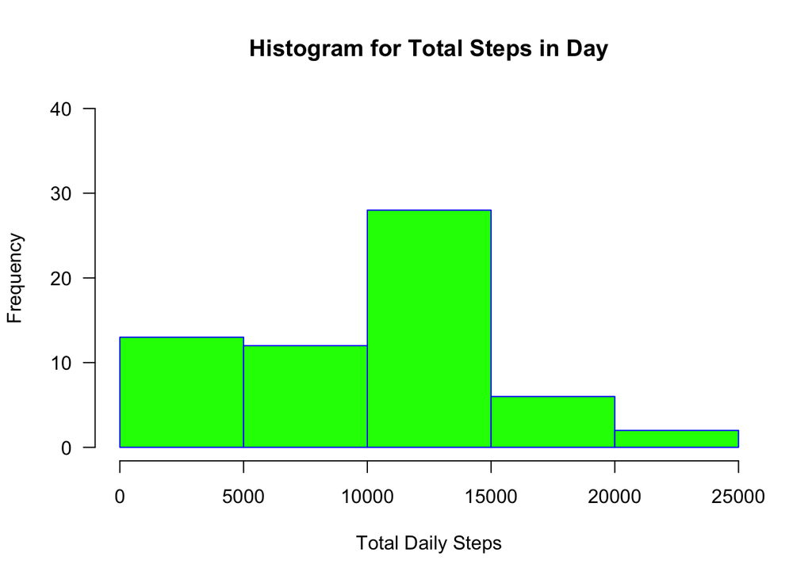

```r
## Make a histogram of the total number of steps taken each day
hist(days_total_steps$sum_steps,
     main="Histogram for Total Steps in Day",
     xlab="Total Daily Steps",
     border="blue",
     col="green",
     ylim=c(0,40),
     las=1,
     breaks=5)
```

```r
## output to look at the data. This should be removed.
days_total_steps
```

```
## Source: local data frame [61 x 3]
##
##          date sum_steps mean_steps
##        (date)     (int)      (dbl)
## 1  2012-10-01         0        NaN
## 2  2012-10-02       126    0.43750
## 3  2012-10-03     11352   39.41667
## 4  2012-10-04     12116   42.06944
## 5  2012-10-05     13294   46.15972
## 6  2012-10-06     15420   53.54167
## 7  2012-10-07     11015   38.24653
## 8  2012-10-08         0        NaN
## 9  2012-10-09     12811   44.48264
## 10 2012-10-10      9900   34.37500
## ..        ...       ...        ...
```

Calculate and report the mean and median of the total number of steps taken per day

```r
## Calculate and report the mean and median of the total number of steps taken per day
total_mean <- mean(days_total_steps$sum_steps, na.rm = TRUE)
total_median <- median(days_total_steps$sum_steps, na.rm = TRUE)
```

Mean number of steps taken per day is 9354.2295082

Median number of steps taken per day is 10395

## What is the average daily activity pattern?

Make a time series plot (i.e. 𝚝𝚢𝚙𝚎 = “𝚕”) of the 5-minute interval (x-axis) and the average number of steps taken, averaged across all days (y-axis)

```r
## sum the steps per day/date and computed mean per day.
interval_total_steps <- summarize(group_by(activityDF, interval),
                              sum_steps = sum(steps, na.rm = TRUE),
                              mean_steps = mean(steps, na.rm = TRUE))

## output to look at the data. This should be removed.
interval_total_steps
```

```
## Source: local data frame [288 x 3]
##
##    interval sum_steps mean_steps
##       (int)     (int)      (dbl)
## 1         0        91  1.7169811
## 2         5        18  0.3396226
## 3        10         7  0.1320755
## 4        15         8  0.1509434
## 5        20         4  0.0754717
## 6        25       111  2.0943396
## 7        30        28  0.5283019
## 8        35        46  0.8679245
## 9        40         0  0.0000000
## 10       45        78  1.4716981
## ..      ...       ...        ...
```

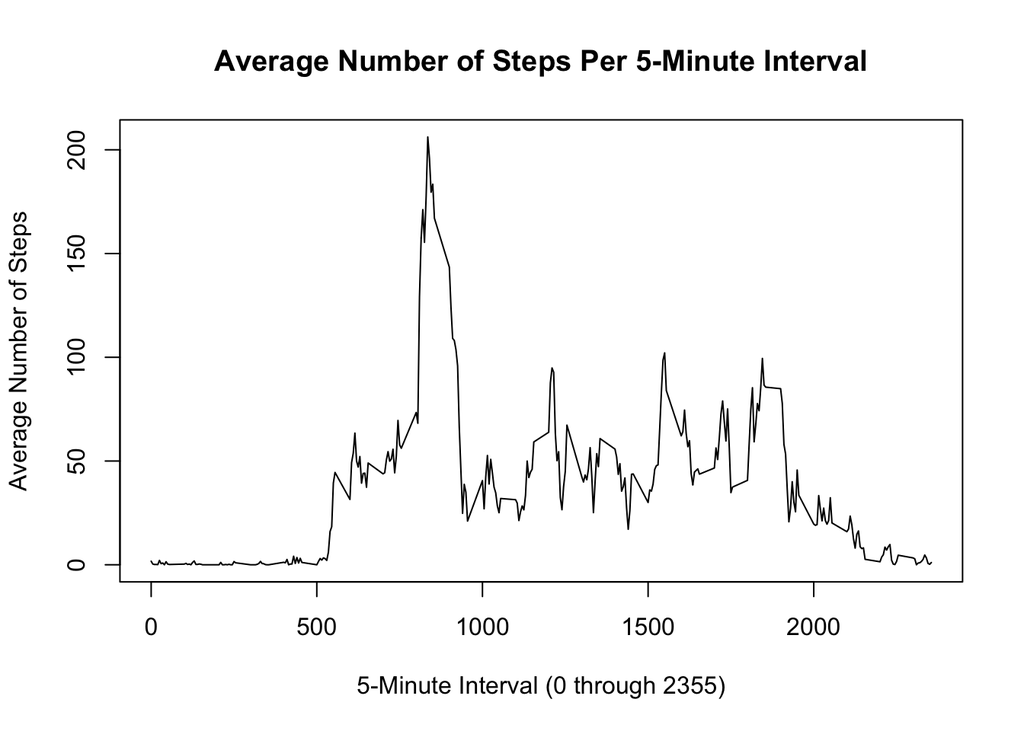

```r
## Make a time series plot (i.e. 𝚝𝚢𝚙𝚎 = "𝚕") of the 5-minute interval (x-axis)
## and the average number of steps taken, averaged across all days (y-axis)
plot(interval_total_steps$interval,
     interval_total_steps$mean_steps,
     type="l",
     main="Average Number of Steps Per 5-Minute Interval",
     xlab="5-Minute Interval (0 through 2355)",
     ylab="Average Number of Steps"
     )
```

Which 5-minute interval, on average across all the days in the dataset, contains the maximum number of steps?

The interval with the maximum number of steps on average across all the days in the dataset is 835